# Analysing Longitundinal Clinical Trials Data

### Assessing the difference in moods from a drug across 6 different time points

# Using R

```r
library(tidyverse)
```

```
✖ ggplot2::%+%()   masks psych::%+%()
```

## Simulate data

|  | Subject | Time | Drug | Mood |
| --- | --- | --- | --- | --- |
| 1 | 1 | 1 | 0 | 7.751762 |
| 2 | 1 | 2 | 0 | 5.765003 |
| 3 | 1 | 3 | 0 | 8.901457 |
| 4 | 1 | 4 | 0 | 8.020293 |
| 5 | 1 | 5 | 1 | 12.138475 |
| 6 | 1 | 6 | 1 | 11.174348 |

|  | vars | n | mean | sd | median | trimmed | mad | min | max | range | skew | kurtosis | se |
| --- | --- | --- | --- | --- | --- | --- | --- | --- | --- | --- | --- | --- | --- |
| Subject | 1 | 900 | 75.50 | 43.32 | 75.50 | 75.50 | 55.60 | 1.00 | 150.00 | 149.00 | 0.00 | -1.20 | 1.44 |
| Time | 2 | 900 | 3.50 | 1.71 | 3.50 | 3.50 | 2.22 | 1.00 | 6.00 | 5.00 | 0.00 | -1.27 | 0.06 |
| Drug | 3 | 900 | 0.51 | 0.50 | 1.00 | 0.51 | 0.00 | 0.00 | 1.00 | 1.00 | -0.03 | -2.00 | 0.02 |
| Mood | 4 | 900 | 9.17 | 2.57 | 8.68 | 9.04 | 2.88 | 4.34 | 15.92 | 11.58 | 0.39 | -0.89 | 0.09 |

The time variable should be centered and scaled to help with interpretation!

## 2. Fit Linear Mixed-Effects Models

```r
# View model summary
summary(model_1)
```

```
Linear mixed model fit by REML ['lmerMod']
Formula: Mood ~ Time_scaled + Drug + (1 | Subject)
   Data: data

REML criterion at convergence: 2777.7

Scaled residuals:
    Min      1Q  Median      3Q     Max
-2.8940 -0.6835  0.0113  0.6922  3.1704

Random effects:
 Groups   Name        Variance  Std.Dev.
 Subject  (Intercept) 1.030e-19 3.209e-10
 Residual             1.268e+00 1.126e+00
Number of obs: 900, groups:  Subject, 150

Fixed effects:
            Estimate Std. Error t value
(Intercept)  7.02978    0.05344  131.53
Time_scaled  0.94045    0.03756   25.04
Drug         4.22803    0.07508   56.31

Correlation of Fixed Effects:
            (Intr) Tm_scl
Time_scaled -0.004
Drug        -0.712  0.005
optimizer (nloptwrap) convergence code: 0 (OK)
boundary (singular) fit: see help('isSingular')
```

This model tests mood as a function of Time and Drug.

Interpretation: Random intercepts allow each subject to have their own baseline mood level, while the fixed effects (Time and Drug) describe overall trends across all subjects.

Random effects: The variance close to 0 indicates there’s almost no variability in baseline mood across individuals. The residual variance is the variability in mood scores that isn’t explained by the model’s fixed effects (Time and Drug). Since the residual variance is low, this suggests that random effects aren’t contributing much to the model’s fit.

Fixed effects: For every 1 SD increase in time, mood increases by 0.94 points (on average for the placebo group), suggesting that mood improves over time regardless of the drug.

If a subject is taking the drug (compared to placebo), their mood increases by 4.23 units on average regardless of time. This is a large effect, implying that the drug has a substantial positive impact on mood.

Correlation of fixed effects:

This small correlation between Time_scaled and Drug indicates that there is almost no multicollinearity between these two variables, so their estimates are stable and independent of one another.

## 3. Fit a More Complex Model with Random Slopes

```r
# View model summary
summary(model_2)
```

```
Linear mixed model fit by REML ['lmerMod']
Formula: Mood ~ Time_scaled * Drug + (Time_scaled | Subject)
   Data: data

REML criterion at convergence: 2572.8

Scaled residuals:
     Min       1Q   Median       3Q      Max
-3.12856 -0.68229 -0.01321  0.65366  3.08505

Random effects:
 Groups   Name        Variance Std.Dev. Corr
 Subject  (Intercept) 0.00000  0.0000
          Time_scaled 0.01903  0.1379    NaN
 Residual             0.98828  0.9941
Number of obs: 900, groups:  Subject, 150

Fixed effects:
                 Estimate Std. Error t value
(Intercept)       7.03355    0.04739 148.408
Time_scaled       0.41250    0.04937   8.355
Drug              4.22584    0.06687  63.193
Time_scaled:Drug  1.02050    0.06728  15.167

Correlation of Fixed Effects:
            (Intr) Tm_scl Drug
Time_scaled -0.006
Drug        -0.715  0.005
Tm_scld:Drg  0.005 -0.705 -0.002
optimizer (nloptwrap) convergence code: 0 (OK)
boundary (singular) fit: see help('isSingular')
```

This model tests mood as a function of Time, Drug, and their interaction (Time × Drug)

Interpretation: The fixed effects include the interaction between Time and Drug, allowing for a changing effect of the drug over time. The random effects allows each subject to have their own baseline mood and a unique trajectory over time.

Random effects: The intercept variances indicates no variation in the baseline mood across subjects. The time variance indicates some variation in how subjects’ mood changes over time, though the variation is very small. This means most subjects follow a similar trend in mood change over time. The residual variance indicates the variability of mood not explained by the fixed or random effects.

Fixed effects: Time_scaled: For every 1 standard deviation increase in time in the placebo group, the mood increases by 0.41 points

Drug: Being in the drug group increases mood by 4.23 points (compared to the placebo group), regardless of time. This is a large effect.

Time_scaled:Drug: This is the interaction effect between Time_scaled and Drug. It means that for those in the drug group, the effect of time on mood is 1.02 points higher per SD increase in time compared to the placebo group. In other words, the mood improvement over time is much greater in the drug group than in the placebo group.

The high t-values indicate significance!

Singular fit: Since there is little variation in baseline mood across subjects, we might consider dropping the random intercept term from the model to simplify it and prevent overfitting.

```r
# View model summary
summary(model_3)
```

```
Linear mixed model fit by REML ['lmerMod']
Formula: Mood ~ Time_scaled * Drug + (0 + Time_scaled | Subject)
   Data: data

REML criterion at convergence: 2572.8

Scaled residuals:
     Min       1Q   Median       3Q      Max
-3.12856 -0.68229 -0.01321  0.65366  3.08505

Random effects:
 Groups   Name        Variance Std.Dev.
 Subject  Time_scaled 0.01903  0.1379
 Residual             0.98828  0.9941
Number of obs: 900, groups:  Subject, 150

Fixed effects:
                 Estimate Std. Error t value
(Intercept)       7.03355    0.04739 148.408
Time_scaled       0.41250    0.04937   8.355
Drug              4.22584    0.06687  63.193
Time_scaled:Drug  1.02050    0.06728  15.167

Correlation of Fixed Effects:
            (Intr) Tm_scl Drug
Time_scaled -0.006
Drug        -0.715  0.005
Tm_scld:Drg  0.005 -0.705 -0.002
```

Everything looks almost identical, but no more singularity warning!

## 4. Visualize!

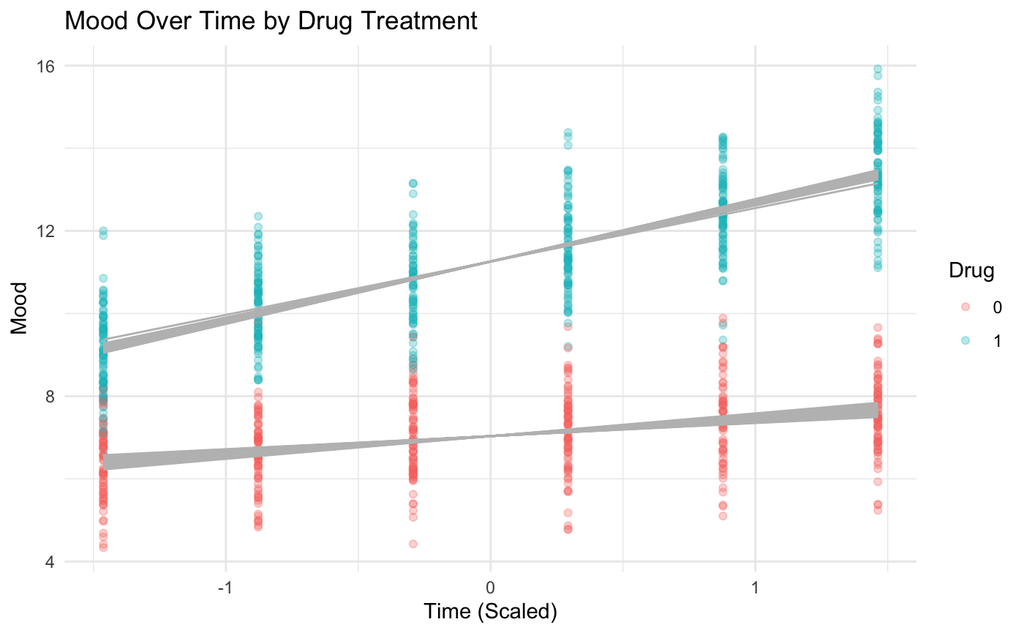

## 5. Compare Models Using Likelihood Ratio Test

```r
# Compare models using ANOVA (likelihood ratio test)
anova(model_1, model_3)
```

```
refitting model(s) with ML (instead of REML)
```

```
Data: data
Models:
model_1: Mood ~ Time_scaled + Drug + (1 | Subject)
model_3: Mood ~ Time_scaled * Drug + (0 + Time_scaled | Subject)
        npar    AIC    BIC  logLik deviance  Chisq Df Pr(>Chisq)
model_1    5 2774.9 2798.9 -1382.5   2764.9
model_3    6 2567.8 2596.7 -1277.9   2555.8 209.07  1  < 2.2e-16 ***
---
Signif. codes:  0 ‘***’ 0.001 ‘**’ 0.01 ‘*’ 0.05 ‘.’ 0.1 ‘ ’ 1
```

Interpretation: AIC (Akaike Information Criterion): A lower AIC indicates a better model fit when comparing models. Model 3 has a lower AIC (2567.8) than Model 1 (2774.9), suggesting it fits the data better.

Actually, all measures indicate Model 3 is better than Model 1! In other words, it is critical to take into the account the interaction effect!

The very low p-value (< 0.001) strongly suggests that the interaction between time and drug treatment is important for explaining the variation in mood.

## 5. Check Model Diagnostics

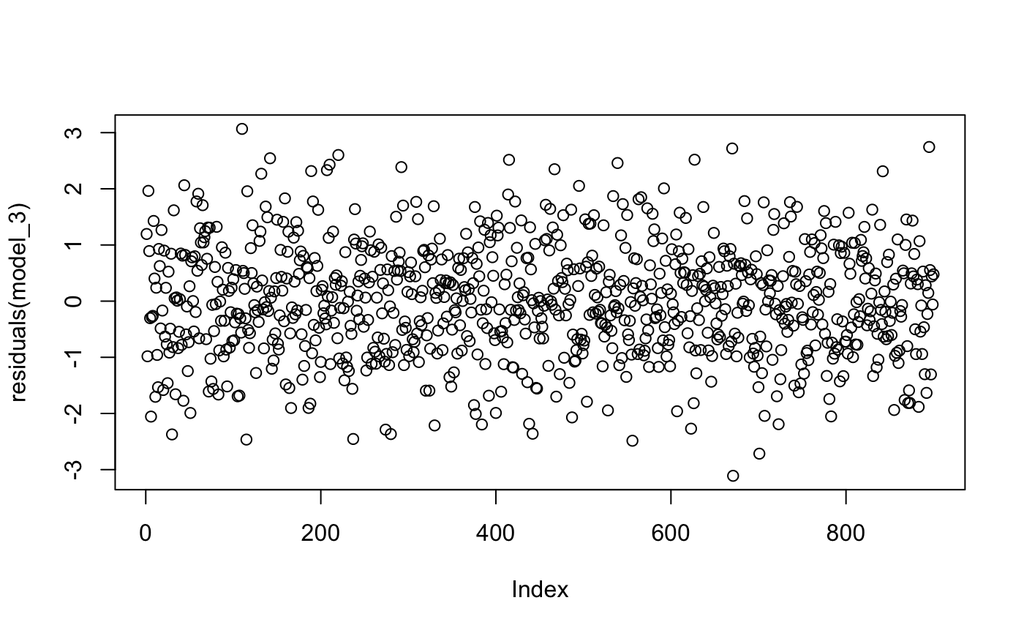

Interpretation: This function retrieves the residuals of the fitted model model_3. Residuals are the differences between the observed values (in your case, Mood) and the predicted values from the model. They indicate how well the model is fitting the data.

After visually inspecting for any patterns or trends, we see random scatter around zero: this indicates that the model is appropriately specified regarding the linearity and homoscedasticity assumptions.

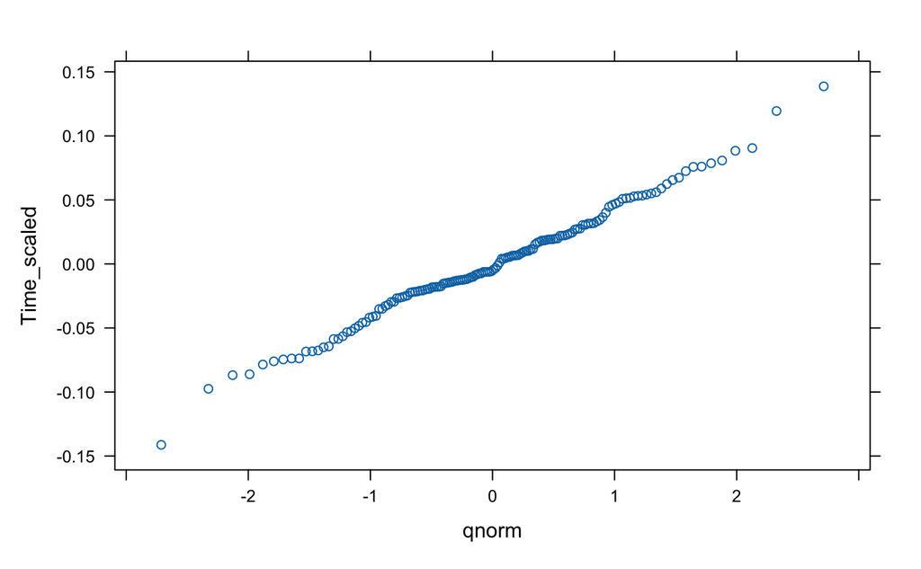

```r
# Random effects plot
plot(ranef(model_3))
```

Interpretation: This function extracts the random effects from the fitted model model_3. Random effects are the components of the model that account for variations attributable to the grouping structure in the data (in this case, Subject). They capture individual differences in the intercepts or slopes based on the random effects specified in the model.

After looking for any notable patterns or clusters in the random effects estimates, we see that the random effects are evenly distributed and vary among subjects: this supports the complexity of your model with random effects.